# Relearning Turing.jl

Author

Laus Wullum

Published

July 30, 2022

## Relearning Turing.jl

The Julia PPL Turing.jl has had some updates. This blog post serves as a very basic introduction on how to work with a Turing.jl model today.

## Data

We will use a dataset from a chapter on longitudinal data in the excellent online book on [Applied Modelling in Drug Development](https://opensource.nibr.com/bamdd/src/02g_longitudinal.html#data) written by statisticians from Novartis.

```julia
using Turing
using CSV
using DataFrames
using TidierData
using TidierPlots
using CategoricalArrays
using FillArrays
using LinearAlgebra
using AlgebraOfGraphics
using CairoMakie


# Load data from the parent folder
adpasi = CSV.read(joinpath("..", "..", "data", "longitudinal.csv"), DataFrame)
#adpasi = CSV.read(joinpath("data", "longitudinal.csv"), DataFrame)

# Name datasets and filter for PASI endpoint at Week12
pasi_data = @chain adpasi begin
    @filter(TRT01P in ["PBO", "TRT"])
    @filter(PARAMCD == "PASITSCO")
    @arrange(AVISITN)
end

xmat = @chain pasi_data begin
    @filter(AVISIT == "Week 12")
    @mutate(TRT01P1 = TRT01P == "TRT")
    @select(TRT01P1, TRT01P, BASE, AVAL)
end

# Design matrix
covariate_mat = [
    xmat[!, "TRT01P1"] parse.(Float64, xmat[!, "BASE"])
]

# Outcome measurements at week 12
pasi_score_week_12 = xmat[!, "AVAL"]
```

```
108-element Vector{Float64}:
 36.7
  2.0
  5.9
  3.8
  0.5
  3.9
  7.7
  6.4
  4.4
 42.6
  ⋮
 20.4
  0.3
 13.2
  4.9
  5.1
  5.4
  2.7
  3.8
  6.7
```

## Overview

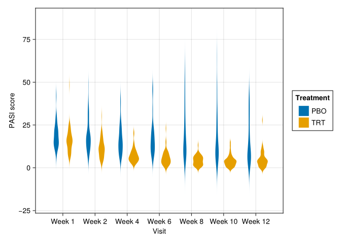

```julia
data(pasi_data) *
    visual(Violin) *
    mapping(
        :AVISIT => "Visit",
        :AVAL => "PASI score",
        color = :TRT01P => "Treatment",
        dodge = :TRT01P,
    ) |>
    draw
```

## Bayesian linear model

We are going to posit the following model, where `TRT01P1` denotes treatment and `BASE` is the baseline PASI score, and AVAL is the outcome score at week 12. The specific prior does not concern us.

More programmatically,

`AVAL ~ BASE + TRT01P`

$$\begin{align}
PASI_i &\sim \mathcal{N}(\beta^T X_i, \sigma^2)\\
\sigma^2 &\sim \mathcal{N}_+ (0, 10^2) \\
\beta_i &\sim \mathcal{N}(0, 10)
\end{align}$$

## Turing.jl model

In Turing.jl this becomes:

```julia
@model function lin_reg(x)
    sigma_sq ~ truncated(Normal(0, 10); lower = 0)
    intercept ~ Normal(0, 10)
    nfeatures = size(x, 2)
    coefficients ~ MvNormal(Zeros(nfeatures), 10.0 * I)
    mu = intercept .+ x * coefficients
    y ~ MvNormal(mu, sigma_sq * I)

    return mean(y)
end
```

```
lin_reg (generic function with 2 methods)
```

## Model object

Now we can define the model unconditionally.

```julia
model = lin_reg(covariate_mat)
```

```
DynamicPPL.Model{typeof(lin_reg), (:x,), (), (), Tuple{Matrix{Float64}}, Tuple{}, DynamicPPL.DefaultContext, false}(lin_reg, (x = [0.0 16.0; 1.0 20.3; … ; 1.0 21.8; 1.0 19.1],), NamedTuple(), DynamicPPL.DefaultContext())
```

With this we can sample from the prior predictive distribution:

```julia
pp_data = rand(model)
```

```
(sigma_sq = 2.6299689043287127, intercept = 5.731365886684755, coefficients = [4.270294035982309, -1.118487027986863], y = [-9.692395739250431, -10.750549634135126, -24.384185242507645, -42.668522176141394, -23.822141556459396, -23.194242219158593, -11.284806802748049, -9.243327951806984, -5.2883564…
```

This yields a named tuple with parameters drawn and data sampled.

We can plot the data envisioned by our prior specification. (The prior predictive distribution is not very good, but that is beside the point here.)

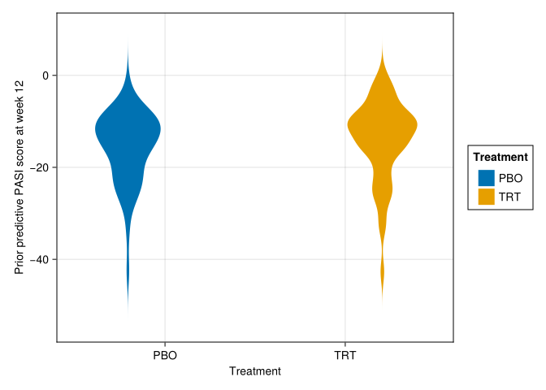

```julia
xmat.AVAL_PP1 = pp_data.y
data(xmat) *
    visual(Violin) *
    mapping(
        :TRT01P => "Treatment",
        :AVAL_PP1 => "Prior predictive PASI score at week 12",
        color = :TRT01P => "Treatment",
        dodge = :TRT01P,
    ) |>
    draw
```

We can also fix the parameters at specific values in the model.

```julia
params_gen = (sigma_sq = 1, coefficients = [0.1, 0.3], intercept = 1)

model_gen = fix(model, params_gen)

rand(model_gen)
```

```
(y = [5.205597313744559, 6.771334506466306, 10.689555673368991, 15.113111600246173, 9.248387157608361, 10.66684337583699, 6.710425394521913, 3.92662816761732, 7.901384011266981, 6.3228237142482575  …  5.853938311832917, 5.27177248983979, 6.552936721489295, 6.875741667809666, 7.0022151742315035, 2.53…
```

We can posit a conditional model on the observed data, to perform inference on the posterior distribution of the parameters.

```julia
model_cond = model | (y = pasi_score_week_12,)
```

```
DynamicPPL.Model{typeof(lin_reg), (:x,), (), (), Tuple{Matrix{Float64}}, Tuple{}, DynamicPPL.ConditionContext{@NamedTuple{y::Vector{Float64}}, DynamicPPL.DefaultContext}, false}(lin_reg, (x = [0.0 16.0; 1.0 20.3; … ; 1.0 21.8; 1.0 19.1],), NamedTuple(), ConditionContext((y = [36.7, 2.0, 5.9, 3.8, 0.…
```

This object can be used to perform inference.

```julia
post_inf_chain = sample(model_cond, NUTS(), 1000)
```

[output not shown]

[output cut: 149 more lines]

[output not shown]

```
Chains MCMC chain (1000×18×1 Array{Float64, 3}):

Iterations        = 501:1:1500
Number of chains  = 1
Samples per chain = 1000
Wall duration     = 33.87 seconds
Compute duration  = 33.87 seconds
parameters        = sigma_sq, intercept, coefficients[1], coefficients[2]
internals         = n_steps, is_accept, acceptance_rate, log_density, hamiltonian_energy, hamiltonian_energy_error, max_hamiltonian_energy_error, tree_depth, numerical_error, step_size, nom_step_size, logprior, loglikelihood, logjoint

Use `describe(chains)` for summary statistics and quantiles.
```

The samples are collected into an `MCMCchain.jl` object, which can be used for convergence diagnostics.

To obtain posterior predictive samples we call `predict` on the model using the posterior draws.

```julia
predict(model, post_inf_chain)
```

```
Chains MCMC chain (1000×108×1 Array{Float64, 3}):

Iterations        = 1:1:1000
Number of chains  = 1
Samples per chain = 1000
parameters        = y[1], y[2], y[3], y[4], y[5], y[6], y[7], y[8], y[9], y[10], y[11], y[12], y[13], y[14], y[15], y[16], y[17], y[18], y[19], y[20], y[21], y[22], y[23], y[24], y[25], y[26], y[27], y[28], y[29], y[30], y[31], y[32], y[33], y[34], y[35], y[36], y[37], y[38], y[39], y[40], y[41], y[…
internals         =

Use `describe(chains)` for summary statistics and quantiles.
```